# Consommation de gaz dans les métropoles françaises

ADUAYOM Daniel & SADIO Ndeye Salimata

## Librairies utiles

```r
options(warn = -1)
library(leaflet)
library(ggplot2)
library(sf)
library(ggmap)
library(maps)
library(tseries)
library(dplyr)
library(forecast)
library(stats)
library(lubridate)
library(dplyr)
library(tidyverse)
set.seed(123)
```

## Lecture des données

```r
donnees <- read.csv2('https://opendata.reseaux-energies.fr/explore/dataset/conso-gaz-metropole/download?format=csv&timezone=Europe/Berlin&use_labels_for_header=false')
```

## Data Preprocessing

### Observation des colonnes

```r
# La colonne geom relate les coordonnées des polygones des métropoles. Or nous n'allons pas utliliser cette information, ainsi nous la supprimons.
donnees$geom <- NULL

# Vérification de données manquantes
nbre_de_donnees_manquantes <- colSums(is.na(donnees))
print(nbre_de_donnees_manquantes)
```

```
##               date code_officiel_epci      nom_metropole          type_epci
##                  0                  0                  0                  0
##       consommation           centroid
##                  0                  0
```

Notre base de donnée est complète.

### Type des données

```r
str(donnees)
```

```
## 'data.frame':    1737 obs. of  6 variables:
##  $ date              : chr  "2019-08" "2019-10" "2021-06" "2021-02" ...
##  $ code_officiel_epci: int  200030195 200039865 200040715 200054781 200093201 200093201 200039865 244500468 243500139 244200770 ...
##  $ nom_metropole     : chr  "Métropole Nice Côte d'Azur" "Metz Métropole" "Grenoble-Alpes-Métropole" "Métropole du Grand Paris" ...
##  $ type_epci         : chr  "ME" "ME" "ME" "ME" ...
##  $ consommation      : num  4.58e+07 1.10e+08 1.09e+08 5.42e+09 1.83e+08 ...
##  $ centroid          : chr  "44.021281136,7.154480276" "49.100843858,6.148999731" "45.141957344,5.718258638" "48.843924589,2.398168904" ...
```

```r
# Convertissons la colonne date qui est de type charactère en Date
donnees$date <- as.Date(paste(donnees$date, "01", sep = "-"), format = "%Y-%m-%d")

# Convertissons la colonne 'centroid' en numeric après avoir tiré la longitude d'une part et
# la latitude d'autre part
donnees[c("latitude", "longitude")] <- t(sapply(strsplit(donnees$centroid, ","),as.numeric))

#Affichage des premières lignes
head(donnees)
```

```
##         date code_officiel_epci                 nom_metropole type_epci
## 1 2019-08-01          200030195    Métropole Nice Côte d'Azur        ME
## 2 2019-10-01          200039865                Metz Métropole        ME
## 3 2021-06-01          200040715      Grenoble-Alpes-Métropole        ME
## 4 2021-02-01          200054781      Métropole du Grand Paris        ME
## 5 2023-06-01          200093201 Métropole Européenne de Lille        ME
## 6 2020-07-01          200093201 Métropole Européenne de Lille        ME
##   consommation                 centroid latitude longitude
## 1     45845557 44.021281136,7.154480276 44.02128  7.154480
## 2    109516682 49.100843858,6.148999731 49.10084  6.149000
## 3    108700809 45.141957344,5.718258638 45.14196  5.718259
## 4   5415149308 48.843924589,2.398168904 48.84392  2.398169
## 5    182586693 50.643899239,3.033354341 50.64390  3.033354
## 6    224573520 50.643899239,3.033354341 50.64390  3.033354
```

## Exploratory Data Analysis (EDA)

### Identifions les villes à plus grosse consommation sur l’année 2023

```r
#Filtre sur 2023
metropoles_data_23 <- subset(donnees, format(date, "%Y") == "2023")

#Consommation moyenne par métropole
data_aggregated <- metropoles_data_23 %>%
  group_by(latitude, longitude,nom_metropole) %>%
  summarise(ConsommationTotale = mean(consommation))
#Représentation de la consommation moyenne par métropole sur la carte de France (Plus le cercle est gros, plus la consommation est importante)
carte_gros_consom <- leaflet(data_aggregated) %>%
  addTiles() %>%
  addCircleMarkers(
    ~longitude, ~latitude,
    radius = ~sqrt(ConsommationTotale) * 0.001,
    color = "red",
    fillOpacity = 0.1,
    popup = ~paste("Ville: ", nom_metropole, "<br>Consommation: ", ConsommationTotale)
  )
carte_gros_consom
```

[interactive chart not shown]

### Base d’apprentissage

Dans le cadre de notre étude, nous allons travailler sur les 2 métropoles les plus consommatrices à savoir Paris et Marseille et notre ville, Rennes.

```r
#Filtre sur les colonnes qui nous intéressent
donnee_filtre <- donnees[, c("date", "nom_metropole","consommation")]

#Filtre sur les trois métropoles retenues
Paris_conso <- subset(donnee_filtre, nom_metropole == "Métropole du Grand Paris")
Marseille_conso <- subset(donnee_filtre, nom_metropole == "Métropole d'Aix-Marseille-Provence")
Rennes_conso<- subset(donnee_filtre, nom_metropole == "Rennes Métropole")

#Fusion
merged_data <- rbind(
  transform(Paris_conso),
  transform(Marseille_conso),
  transform(Rennes_conso)
)

#Vérification du type des colonnes
str(merged_data)
```

```
## 'data.frame':    252 obs. of  3 variables:
##  $ date         : Date, format: "2021-02-01" "2018-01-01" ...
##  $ nom_metropole: chr  "Métropole du Grand Paris" "Métropole du Grand Paris" "Métropole du Grand Paris" "Métropole du Grand Paris" ...
##  $ consommation : num  5.42e+09 5.72e+09 2.84e+09 7.42e+08 4.17e+09 ...
```

```r
#Aperçu des données
head(merged_data)
```

```
##           date            nom_metropole consommation
## 4   2021-02-01 Métropole du Grand Paris   5415149308
## 36  2018-01-01 Métropole du Grand Paris   5724576949
## 76  2022-04-01 Métropole du Grand Paris   2836670580
## 122 2020-07-01 Métropole du Grand Paris    741632366
## 242 2017-03-01 Métropole du Grand Paris   4167184403
## 253 2018-02-01 Métropole du Grand Paris   7107338535
```

### Présence d’outliers

Testons la présence d’outliers. S’il y en a, ils seront coloriés en rouge.

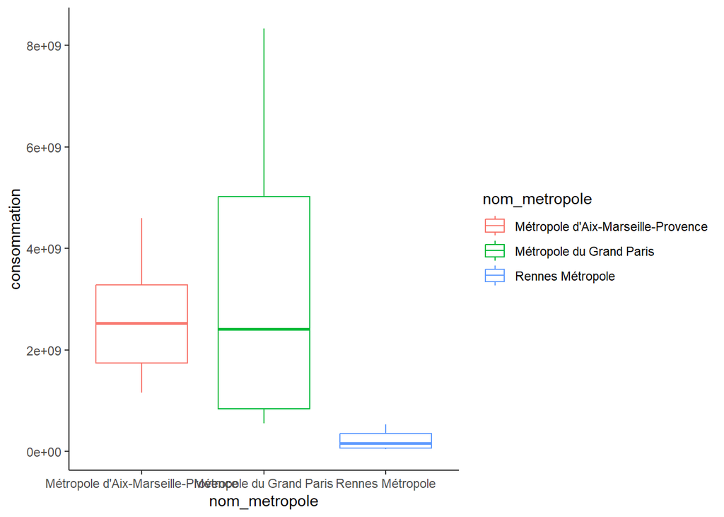

```r
ggplot(outlier.colour = "red", merged_data, aes(x = nom_metropole, y = consommation, color = nom_metropole)) +
  geom_boxplot() +
  theme_classic()
```

Il n’y a pas d’outliers.

### Evolution de la consommation de gaz dans le temps

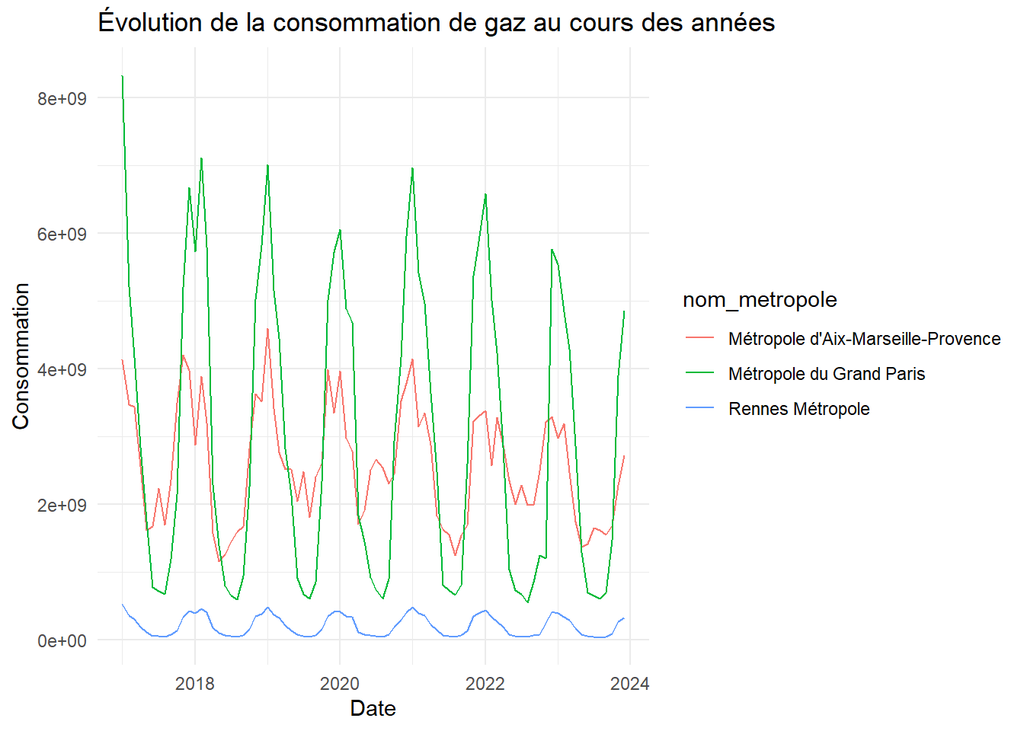

```r
ggplot(merged_data, aes(x = date, y = consommation, color = nom_metropole)) +
  geom_line() +
  labs(title = "Évolution de la consommation de gaz au cours des années",
       x = "Date",
       y = "Consommation") +
  theme_minimal()
```

On note une baisse en 2020, certainement liée au covid. Néanmoins, il y a une périodicité.

### Résumé Statistique

```r
summary(Rennes_conso)
```

```
##       date            nom_metropole       consommation
##  Min.   :2017-01-01   Length:84          Min.   : 38442823
##  1st Qu.:2018-09-23   Class :character   1st Qu.: 63621112
##  Median :2020-06-16   Mode  :character   Median :162284909
##  Mean   :2020-06-16                      Mean   :208643140
##  3rd Qu.:2022-03-08                      3rd Qu.:349799277
##  Max.   :2023-12-01                      Max.   :528363856
```

```r
summary(Marseille_conso)
```

```
##       date            nom_metropole       consommation
##  Min.   :2017-01-01   Length:84          Min.   :1.153e+09
##  1st Qu.:2018-09-23   Class :character   1st Qu.:1.735e+09
##  Median :2020-06-16   Mode  :character   Median :2.520e+09
##  Mean   :2020-06-16                      Mean   :2.583e+09
##  3rd Qu.:2022-03-08                      3rd Qu.:3.283e+09
##  Max.   :2023-12-01                      Max.   :4.594e+09
```

```r
summary(Paris_conso)
```

```
##       date            nom_metropole       consommation
##  Min.   :2017-01-01   Length:84          Min.   :5.493e+08
##  1st Qu.:2018-09-23   Class :character   1st Qu.:8.384e+08
##  Median :2020-06-16   Mode  :character   Median :2.410e+09
##  Mean   :2020-06-16                      Mean   :3.019e+09
##  3rd Qu.:2022-03-08                      3rd Qu.:5.014e+09
##  Max.   :2023-12-01                      Max.   :8.327e+09
```

### Focus sur l’évolution de la consommation durant l’année 2023

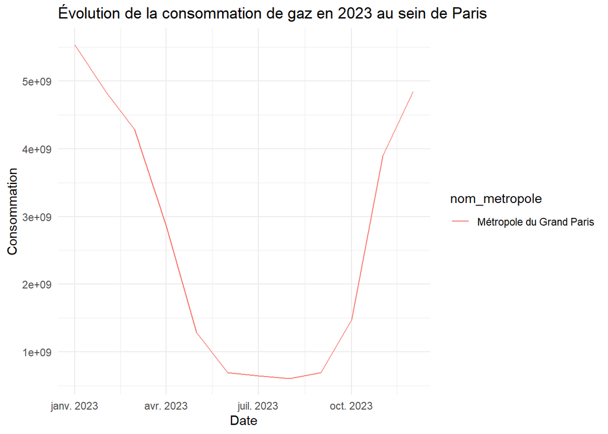

```r
data <- subset(Paris_conso, date >= as.Date("2023-01-01") & date <= as.Date("2023-12-31"))
ggplot(data, aes(x = date, y = consommation, color = nom_metropole)) +
  geom_line() +
  labs(title = "Évolution de la consommation de gaz en 2023 au sein de Paris",
       x = "Date",
       y = "Consommation") +
  theme_minimal()
```

On note une baisse durant l’été , ce qui nous fait penser que la saison peut être une variable explicative.

## Feature engineering: variable saison {Hiver, Printemps , Ete, Automne}

```r
#Fonction de conversion du mois en saison
month_to_season <- function(mois) {
  mois <- as.numeric(mois)

  if (mois %in% 1:3) {
    return("Hiver")
  } else if (mois %in% 4:6) {
    return("Printemps")
  } else if (mois %in% 7:9) {
    return("Ete")
  } else if (mois %in% 10:12) {
    return("Automne")
  } else {
    return("Mois inconnu")
  }
}

#Application à notre jeu de données
merged_data <- merged_data %>% mutate(saison = sapply(month(merged_data$date), month_to_season))

#Vérification
unique(merged_data$saison)
```

```
## [1] "Hiver"     "Printemps" "Ete"       "Automne"
```

```r
#Aperçu des données
head(merged_data)
```

```
##           date            nom_metropole consommation    saison
## 4   2021-02-01 Métropole du Grand Paris   5415149308     Hiver
## 36  2018-01-01 Métropole du Grand Paris   5724576949     Hiver
## 76  2022-04-01 Métropole du Grand Paris   2836670580 Printemps
## 122 2020-07-01 Métropole du Grand Paris    741632366       Ete
## 242 2017-03-01 Métropole du Grand Paris   4167184403     Hiver
## 253 2018-02-01 Métropole du Grand Paris   7107338535     Hiver
```

### Consommation de gaz suivant les saisons et les métropoles

```r
df_grouped <- merged_data %>%
  group_by(nom_metropole, saison) %>%
  summarise(Moyenne_Consommation = mean(consommation))
```

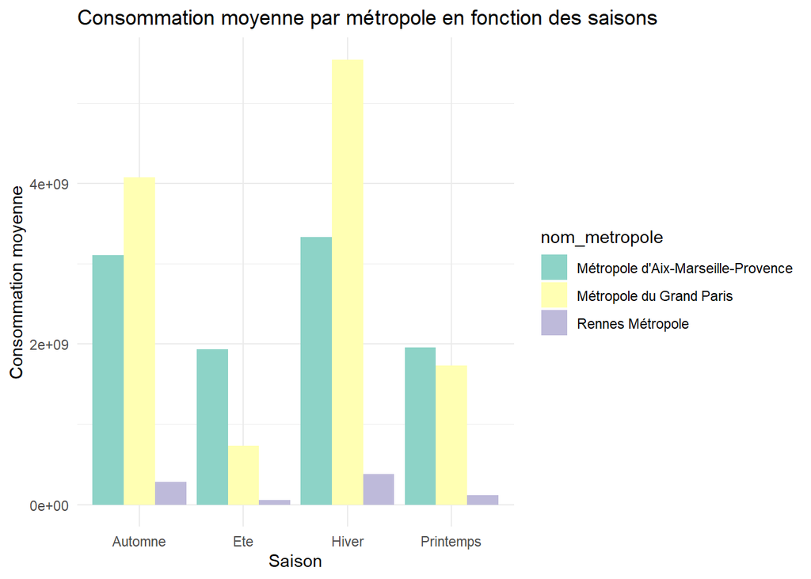

```r
ggplot(df_grouped, aes(x = saison, y = Moyenne_Consommation, fill = nom_metropole)) +
  geom_bar(stat = "identity", position = "dodge") +
  labs(title = "Consommation moyenne par métropole en fonction des saisons",
       x = "Saison",
       y = "Consommation moyenne") +
  theme_minimal() +
  scale_fill_brewer(palette = "Set3")
```

Nous notons clairement qu’il y a une baisse de consommation durant l’été et le printemps.

## Série Temporelle

### Conversion en série temporelle

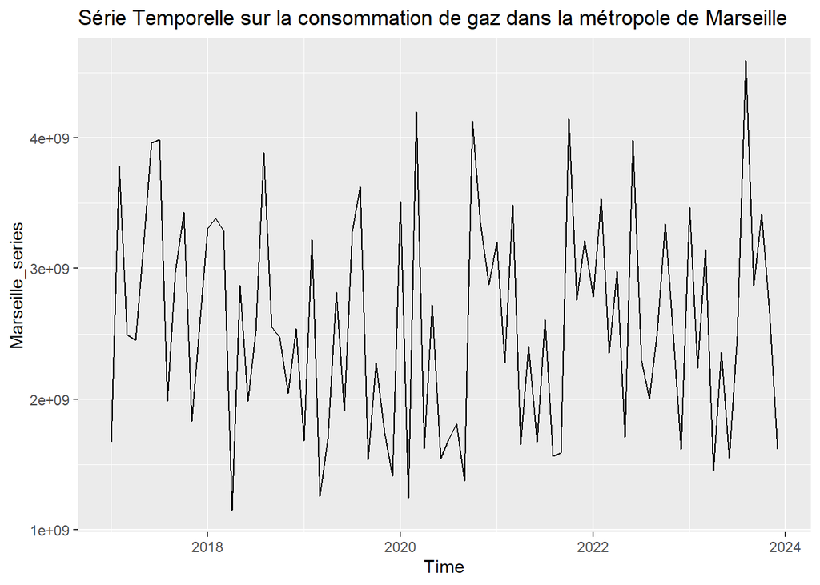

```r
Paris_series <- ts(Paris_conso$consommation, start = c(2017, 1), frequency = 12)
Marseille_series <- ts(Marseille_conso$consommation, start = c(2017, 1), frequency = 12)
Rennes_series <- ts(Rennes_conso$consommation, start = c(2017, 1), frequency = 12)

#Représentation de la série sur Marseille en guise d'exemple
autoplot(Marseille_series)  +
  labs(title = "Série Temporelle sur la consommation de gaz dans la métropole de Marseille")
```

### Décomposition des séreies temporelles

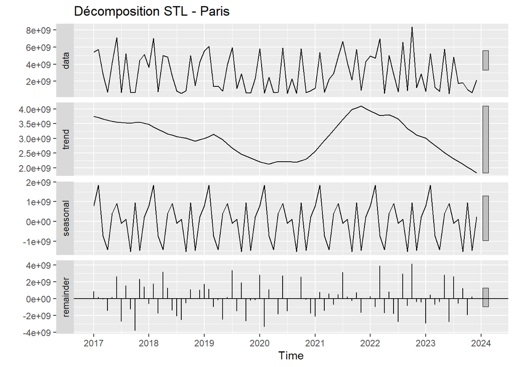

```r
decomposition_R <- stl(Rennes_series, s.window = "periodic")
decomposition_P <- stl(Paris_series, s.window = "periodic")
decomposition_M <- stl(Marseille_series, s.window = "periodic")

# Afficher la décomposition
autoplot(decomposition_P) + labs(title = "Décomposition STL - Paris")
```

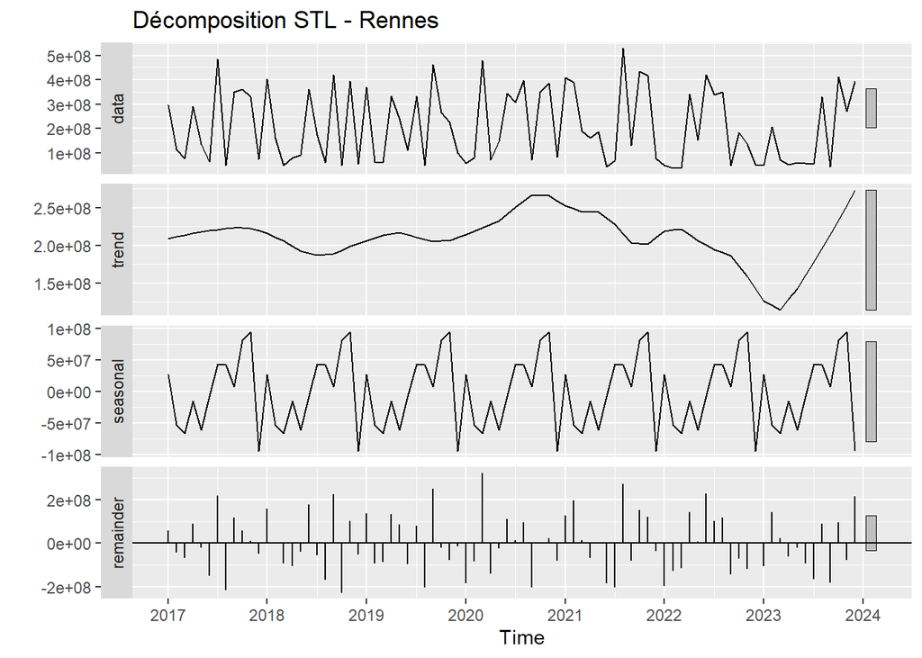

```r
autoplot(decomposition_R) + labs(title = "Décomposition STL - Rennes")
```

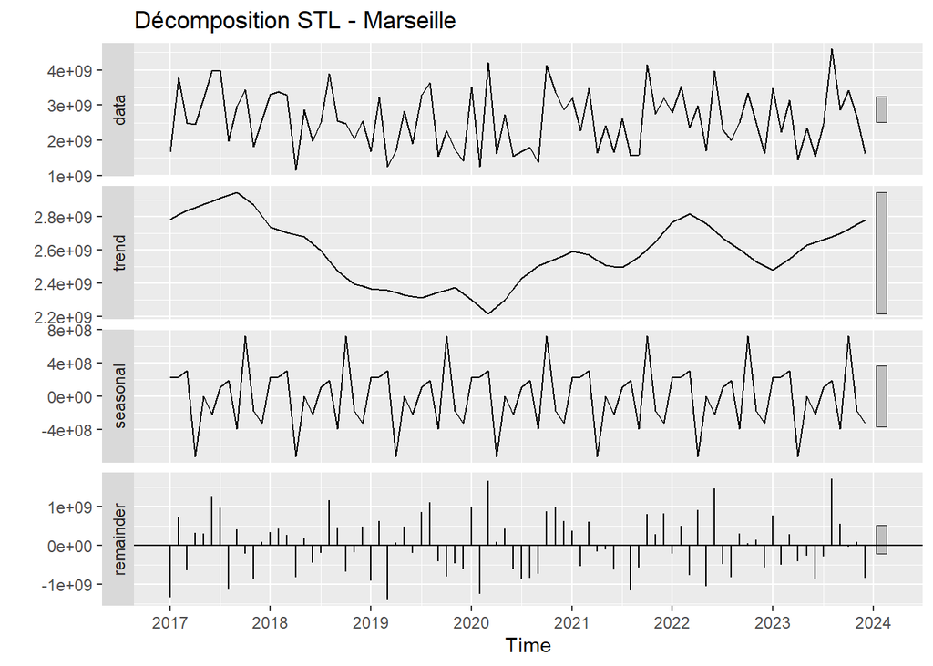

```r
autoplot(decomposition_M) + labs(title = "Décomposition STL - Marseille")
```

On note une tendance au sein de notre série, et une baisse de la consommation de l’énergie dans les différentes métropoles, à partir dans le mois d’aout et septembre. A priori, il y a une tendance assez similaire dans les deux grandes villes, mais une différence de tendance pour la métropole de Rennes.

## Model Selection

### Tests de stationnarité

```r
# Effectuons le test augmenté de Dickey-Fuller
adf_test_paris <- adf.test(Paris_series)
adf_test_marseille <- adf.test(Marseille_series)
adf_test_rennes <- adf.test(Rennes_series)

kpss_test_paris <-kpss.test(Paris_series)
kpss_test_marseille <-kpss.test(Marseille_series)
kpss_test_rennes <-kpss.test(Rennes_series)

# Affichons les résultats du test
print(adf_test_paris)
```

```
##
##  Augmented Dickey-Fuller Test
##
## data:  Paris_series
## Dickey-Fuller = -3.4492, Lag order = 4, p-value = 0.0529
## alternative hypothesis: stationary
```

```r
print(adf_test_marseille)
```

```
##
##  Augmented Dickey-Fuller Test
##
## data:  Marseille_series
## Dickey-Fuller = -4.3558, Lag order = 4, p-value = 0.01
## alternative hypothesis: stationary
```

```r
print(adf_test_rennes)
```

```
##
##  Augmented Dickey-Fuller Test
##
## data:  Rennes_series
## Dickey-Fuller = -4.8363, Lag order = 4, p-value = 0.01
## alternative hypothesis: stationary
```

```r
print(kpss_test_paris)
```

```
##
##  KPSS Test for Level Stationarity
##
## data:  Paris_series
## KPSS Level = 0.14317, Truncation lag parameter = 3, p-value = 0.1
```

```r
print(kpss_test_marseille)
```

```
##
##  KPSS Test for Level Stationarity
##
## data:  Marseille_series
## KPSS Level = 0.10995, Truncation lag parameter = 3, p-value = 0.1
```

```r
print(kpss_test_rennes)
```

```
##
##  KPSS Test for Level Stationarity
##
## data:  Rennes_series
## KPSS Level = 0.08233, Truncation lag parameter = 3, p-value = 0.1
```

### Auto corrélations et autocorélations paritelles

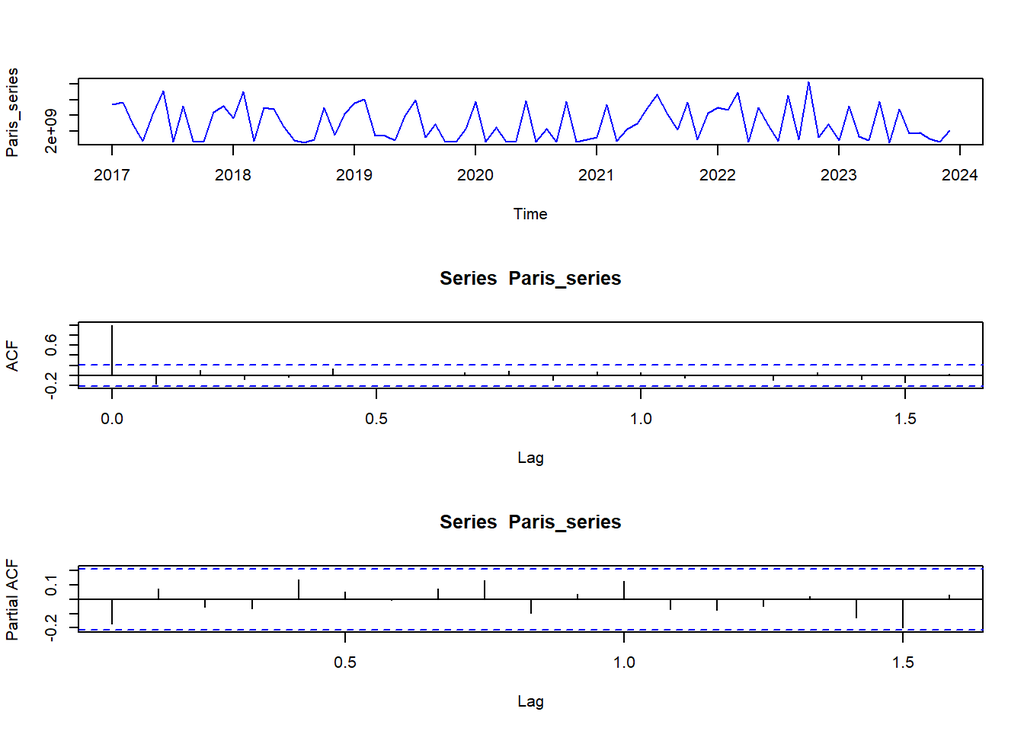

```r
par(mfrow=c(3,1))
plot(Paris_series, type = "l", col = "blue")
acf(Paris_series)
pacf(Paris_series)
```

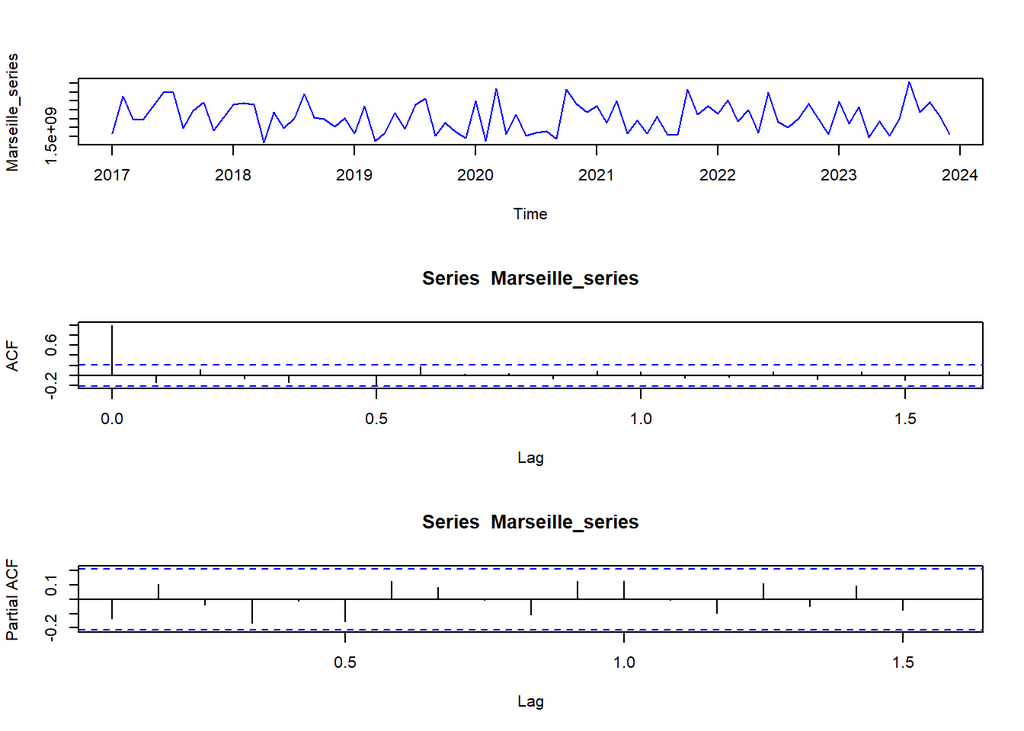

```r
par(mfrow=c(3,1))
plot(Marseille_series, type = "l", col = "blue")
acf(Marseille_series)
pacf(Marseille_series)
```

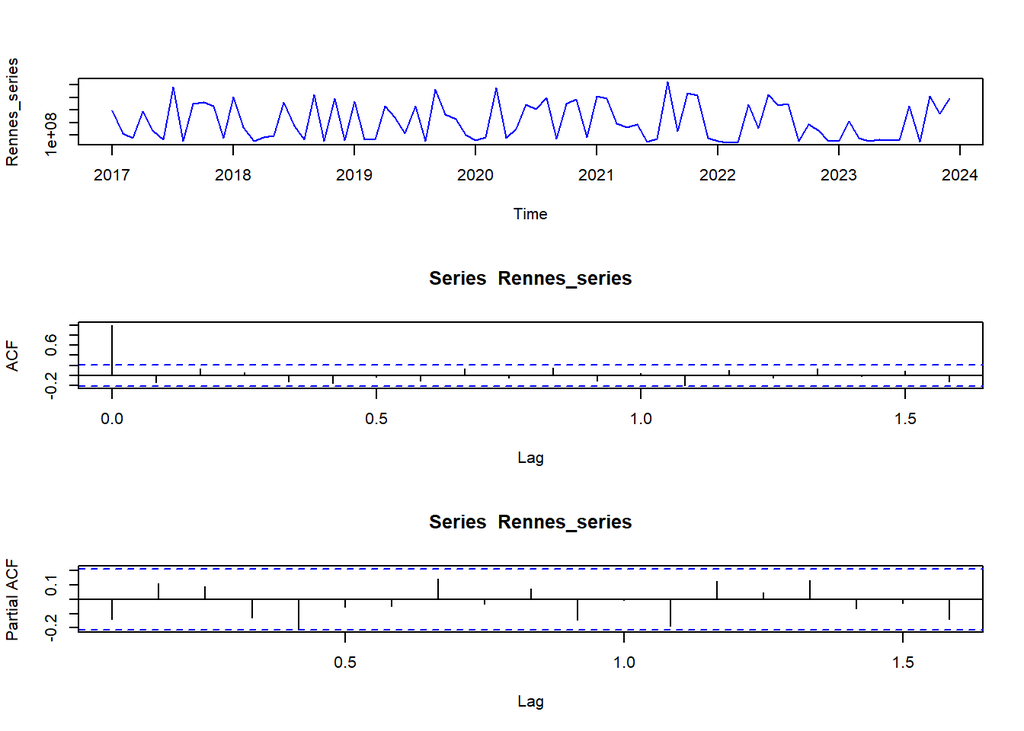

```r
par(mfrow=c(3,1))
plot(Rennes_series, type = "l", col = "blue")
acf(Rennes_series)
pacf(Rennes_series)
```

### Normalisation

Les trois séries ont des échelles différentes donc afin de pouvoir comparer nos futurs résultats, nous allons procéder à une normalisation.

```r
mean_val <- mean(Marseille_series)
sd_val <- sd(Marseille_series)
Marseille_series_norm <- (Marseille_series - mean_val) / sd_val

mean_val <- mean(Paris_series)
sd_val <- sd(Paris_series)
Paris_series_norm <- (Paris_series - mean_val) / sd_val

mean_val <- mean(Rennes_series)
sd_val <- sd(Rennes_series)
Rennes_series_norm <- (Rennes_series - mean_val) / sd_val

liste_series_temporelles <- list(Marseille_series_norm, Paris_series_norm, Rennes_series_norm)
liste_series_temporelles
```

```
## [[1]]
##              Jan         Feb         Mar         Apr         May         Jun
## 2017 -1.07103906  1.41409612 -0.10303239 -0.15270269  0.70802797  1.62491224
## 2018  0.84991539  0.94314957  0.83293949 -1.68372532  0.33857516 -0.70211264
## 2019 -1.06164772  0.75402517 -1.55846098 -1.04290612  0.27993338 -0.79185332
## 2020  1.09457669 -1.57509288  1.90341115 -1.12918299  0.16262820 -1.21996400
## 2021  0.73059431 -0.36041583  1.06601019 -1.09402143 -0.21023393 -1.07170098
## 2022  0.23481276  1.11662393 -0.27152964  0.46443844 -1.02630648  1.64371170
## 2023  1.04488572 -0.40436368  0.66600448 -1.33150069 -0.26388271 -1.21568889
##              Jul         Aug         Sep         Oct         Nov         Dec
## 2017  1.65174933 -0.70367111  0.45750197  0.99867376 -0.88457659 -0.01384026
## 2018 -0.07466749  1.53639058 -0.03166555 -0.12613821 -0.62990621 -0.04783274
## 2019  0.82058167  1.22959034 -1.22846539 -0.35500530 -0.98909242 -1.38035533
## 2020 -1.05008718 -0.90740251 -1.42394146  1.82306356  0.90523815  0.34545278
## 2021  0.03208187 -1.19581873 -1.16865772  1.83934172  0.20680947  0.74046744
```

[output cut: 46 more lines]

### Critères d’évaluation de la qualité des modèles: AIC et BIC

```r
#Fonction qui retourne les résultats avec le critère BIC
test_combinaisons_modeles_BIC <- function(serie, ordre_max = 3) {
  bic_resultats <- matrix(NA, ncol = 3, nrow = ordre_max^2)
  colnames(bic_resultats) <- c("AR", "MA", "BIC")
  k <- 1
  for (p in 1:ordre_max) {
    for (q in 1:ordre_max) {
      ordre_modele <- c(p, 0, q)
      modele <- arima(serie, order = ordre_modele, method = "ML")
      bic_resultats[k, ] <- c(p, q, BIC(modele))
      k <- k + 1
    }
  }
  return(bic_resultats)
}

#Fonction qui retourne les résultats avec le critère AIC
test_combinaisons_modeles_AIC <- function(serie, ordre_max = 3) {
  aic_resultats <- matrix(NA, ncol = 3, nrow = ordre_max^2)
  colnames(aic_resultats) <- c("AR", "MA", "AIC")
  k <- 1
  for (p in 1:ordre_max) {
    for (q in 1:ordre_max) {
      ordre_modele <- c(p, 0, q)
      modele <- arima(serie, order = ordre_modele, method = "ML")
      aic_resultats[k, ] <- c(p, q, AIC(modele))
      k <- k + 1
    }
  }
  return(aic_resultats)
}
```

### Résultats des tests

```r
# Application de la fonction à chaque série temporelle
resultats_AIC <- lapply(liste_series_temporelles, test_combinaisons_modeles_AIC)
resultats_BIC <- lapply(liste_series_temporelles, test_combinaisons_modeles_BIC)
print(resultats_AIC)
```

```
## [[1]]
##       AR MA      AIC
##  [1,]  1  1 243.2370
##  [2,]  1  2 244.4491
##  [3,]  1  3 245.2564
##  [4,]  2  1 244.7816
##  [5,]  2  2 240.1085
##  [6,]  2  3 244.9539
##  [7,]  3  1 245.5360
##  [8,]  3  2 244.5793
##  [9,]  3  3 247.0798
##
## [[2]]
##       AR MA      AIC
##  [1,]  1  1 242.3498
```

[output cut: 20 more lines]

```r
print(resultats_BIC)
```

```
## [[1]]
##       AR MA      BIC
##  [1,]  1  1 252.9603
##  [2,]  1  2 256.6032
##  [3,]  1  3 259.8413
##  [4,]  2  1 256.9357
##  [5,]  2  2 254.6934
##  [6,]  2  3 261.9697
##  [7,]  3  1 260.1209
##  [8,]  3  2 261.5950
##  [9,]  3  3 266.5263
##
## [[2]]
##       AR MA      BIC
##  [1,]  1  1 252.0731
```

[output cut: 20 more lines]

On constate que l’AIC donne de meilleurs résultats que le BIC.

### Data Training

```r
#Fonction qui effectue l'apprentissage, retourne les résultats
#Cette fonction prend en entrée la série, la série normée, les ordres et le nom de la série
#Elle retourne les résultats et le RMSE

plotARMAForecast <- function(series, series_norm, order_arma,name_series) {
  # Déterminez la taille de l'échantillon d'entraînement
  train_size <- floor(0.8 * length(series_norm))
  train_data <- series_norm[1:train_size]
  test_data <- series_norm[(train_size + 1):length(series_norm)]

  # Mise en place du modèle ARMA
  modele_arma <- arima(train_data, order = order_arma)

  # Faites des prédictions sur l'échantillon de test
  predictions <- predict(modele_arma, n.ahead = length(test_data))

  # Dénormalisez les prédictions et les données d'entraînement/test
  predictions_denorm <- (predictions$pred * sd(series)) + mean(series)
  test_data_denorm <- (test_data * sd(series)) + mean(series)
  train_data_denorm <- (train_data * sd(series)) + mean(series)

  # Créez une séquence de dates pour l'échantillon de test
  dates_test <- seq_along(test_data)

  # Créez une séquence de dates pour l'échantillon d'entraînement et de test
  dates_train <- seq_along(train_data)
  dates_test <- seq_along(test_data) + length(train_data)

  # Tracez la série d'entraînement, la série de test et les prédictions
  # Plot avec la série d'entraînement, la série de test_data et les prédictions en bleu pour     la série de test
  plot(c(dates_train, dates_test), c(train_data_denorm, test_data_denorm), type = 'l', col = 'black', xlab = 'Time', ylab = 'Value',
       ylim = range(c(train_data_denorm, test_data_denorm, predictions_denorm)))
  lines(dates_test, test_data_denorm, col = 'blue')  # Modifier la couleur en bleu
  lines(dates_test, predictions_denorm, col = 'red')
  legend("topright", legend = c("Train Data", "Test Data", "Predictions"), col = c('black', 'blue', 'red'), lty = 1, cex = 0.5)
  title(main = "", sub = name_series, line = 4, cex.main = 1.5, col.main = "black", font.main = 2)

  # Calcul du RMSE
  rmse <- sqrt(mean((predictions_denorm - test_data_denorm)^2))
  cat("RMSE for", name_series, ":", rmse, "\n")

}
```

#Application à nos séries

```r
par(mfrow = c(2, 2))

plotARMAForecast(Paris_series, Paris_series_norm, c(3, 0, 1), "Paris")
```

```
## RMSE for Paris : 2363954467
```

```r
plotARMAForecast(Marseille_series,Marseille_series_norm, c(1, 0, 2),"Marseille")
```

```
## RMSE for Marseille : 828326567
```

```
## RMSE for Rennes : 149890064
```

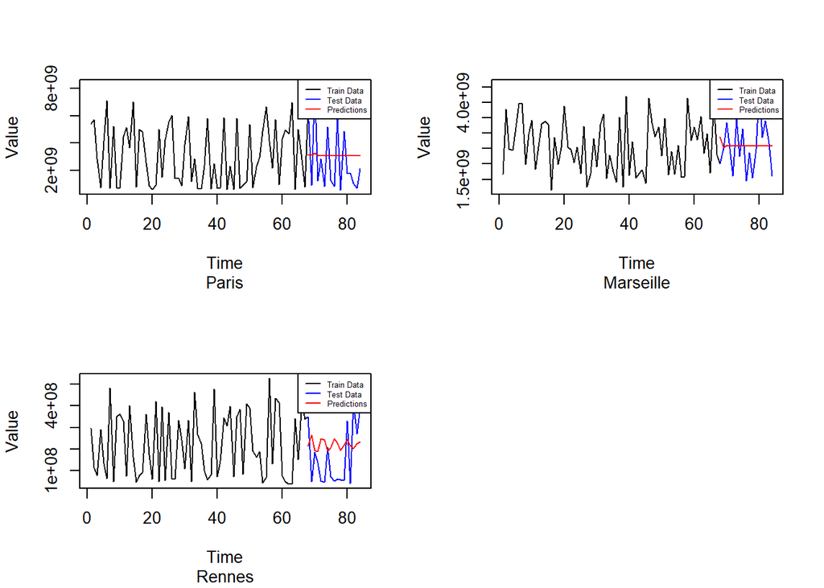

```r
plotARMAForecast(Rennes_series,Rennes_series_norm, c(3, 0, 2),"Rennes")
```

## Modèle SARIMA

```r
#Différenciations
ndiffs(Paris_series)
```

```
## [1] 0
```

```r
ndiffs(Rennes_series)
```

```
## [1] 0
```

```r
ndiffs(Marseille_series)
```

```
## [1] 0
```

```r
#Fonction qui effectue l'apprentissage, retourne les résultats
#Cette fonction prend en entrée la série, la série normée, les ordres et le nom de la série
#Elle retourne les résultats et le RMSE
plotSARIMAForecast <- function(series, series_norm, order_arma,order_season,name_series) {
  # Déterminez la taille de l'échantillon d'entraînement
  train_size <- floor(0.8 * length(series_norm))
  train_data <- series_norm[1:train_size]
  test_data <- series_norm[(train_size + 1):length(series_norm)]

  # Mise en place du modèle ARMA
  modele_arma <- arima(series_norm, order = order_arma,
                       seasonal = list(order = order_season),
                       include.mean = FALSE,
                       method = "ML")


  # Faites des prédictions sur l'échantillon de test
  predictions <- predict(modele_arma, n.ahead = length(test_data))

  # Dénormalisez les prédictions et les données d'entraînement/test
  predictions_denorm <- (predictions$pred * sd(series)) + mean(series)
  test_data_denorm <- (test_data * sd(series)) + mean(series)
  train_data_denorm <- (train_data * sd(series)) + mean(series)

  # Créez une séquence de dates pour l'échantillon de test
  dates_test <- seq_along(test_data)

  # Créez une séquence de dates pour l'échantillon d'entraînement et de test
  dates_train <- seq_along(train_data)
  dates_test <- seq_along(test_data) + length(train_data)

  # Tracé

  # Tracez la série d'entraînement, la série de test_data et les prédictions

  plot(c(dates_train, dates_test), c(train_data, test_data), type = 'l', col = 'black', xlab = 'Time', ylab = 'Value',
       ylim = range(c(train_data, test_data, predictions$pred)))
  lines(dates_test, test_data, col = 'blue')  # Modifier la couleur en vert
  lines(dates_test, predictions$pred, col = 'red')
  legend("topright", legend = c("Train Data", "Test Data", "Predictions"), col = c('black', 'blue', 'red'), lty = 1, cex = 0.5)
  title(main = "", sub = name_series, line = 4, cex.main = 1.5, col.main = "black", font.main = 2)

  # Calcul du RMSE
  rmse <- sqrt(mean((predictions_denorm - test_data_denorm)^2))
  cat("RMSE for", name_series, ":", rmse, "\n")

}
```

#Déterminons P, Q et D.

```r
auto_sarima <- auto.arima(Marseille_series_norm, D=1, trace=TRUE)
```

```
##
##  ARIMA(2,0,2)(1,1,1)[12] with drift         : Inf
##  ARIMA(0,0,0)(0,1,0)[12] with drift         : 250.2322
##  ARIMA(1,0,0)(1,1,0)[12] with drift         : 242.5845
##  ARIMA(0,0,1)(0,1,1)[12] with drift         : Inf
##  ARIMA(0,0,0)(0,1,0)[12]                    : 248.1813
##  ARIMA(1,0,0)(0,1,0)[12] with drift         : 249.3221
##  ARIMA(1,0,0)(2,1,0)[12] with drift         : 239.6728
##  ARIMA(1,0,0)(2,1,1)[12] with drift         : Inf
##  ARIMA(1,0,0)(1,1,1)[12] with drift         : Inf
##  ARIMA(0,0,0)(2,1,0)[12] with drift         : 237.8123
##  ARIMA(0,0,0)(1,1,0)[12] with drift         : 241.277
##  ARIMA(0,0,0)(2,1,1)[12] with drift         : Inf
##  ARIMA(0,0,0)(1,1,1)[12] with drift         : Inf
##  ARIMA(0,0,1)(2,1,0)[12] with drift         : 239.782
##  ARIMA(1,0,1)(2,1,0)[12] with drift         : 241.1272
##  ARIMA(0,0,0)(2,1,0)[12]                    : 235.6026
##  ARIMA(0,0,0)(1,1,0)[12]                    : 239.1985
##  ARIMA(0,0,0)(2,1,1)[12]                    : Inf
##  ARIMA(0,0,0)(1,1,1)[12]                    : Inf
##  ARIMA(1,0,0)(2,1,0)[12]                    : 237.4061
##  ARIMA(0,0,1)(2,1,0)[12]                    : 237.5125
##  ARIMA(1,0,1)(2,1,0)[12]                    : 238.7966
##
##  Best model: ARIMA(0,0,0)(2,1,0)[12]
```

```r
auto_sarima <- auto.arima(Paris_series_norm, D=1, trace=TRUE)
```

```
##
##  ARIMA(2,0,2)(1,1,1)[12] with drift         : Inf
##  ARIMA(0,0,0)(0,1,0)[12] with drift         : 252.999
##  ARIMA(1,0,0)(1,1,0)[12] with drift         : 229.2008
##  ARIMA(0,0,1)(0,1,1)[12] with drift         : Inf
##  ARIMA(0,0,0)(0,1,0)[12]                    : 251.2798
##  ARIMA(1,0,0)(0,1,0)[12] with drift         : 252.2763
##  ARIMA(1,0,0)(2,1,0)[12] with drift         : 230.3556
##  ARIMA(1,0,0)(1,1,1)[12] with drift         : 226.2208
##  ARIMA(1,0,0)(0,1,1)[12] with drift         : Inf
##  ARIMA(1,0,0)(2,1,1)[12] with drift         : Inf
##  ARIMA(1,0,0)(1,1,2)[12] with drift         : 227.2372
##  ARIMA(1,0,0)(0,1,2)[12] with drift         : Inf
##  ARIMA(1,0,0)(2,1,2)[12] with drift         : Inf
##  ARIMA(0,0,0)(1,1,1)[12] with drift         : 226.2653
##  ARIMA(2,0,0)(1,1,1)[12] with drift         : 226.7255
##  ARIMA(1,0,1)(1,1,1)[12] with drift         : 227.8555
##  ARIMA(0,0,1)(1,1,1)[12] with drift         : 226.8481
##  ARIMA(2,0,1)(1,1,1)[12] with drift         : 228.8045
##  ARIMA(1,0,0)(1,1,1)[12]                    : 224.2308
##  ARIMA(1,0,0)(0,1,1)[12]                    : Inf
##  ARIMA(1,0,0)(1,1,0)[12]                    : 227.3639
##  ARIMA(1,0,0)(2,1,1)[12]                    : Inf
##  ARIMA(1,0,0)(1,1,2)[12]                    : 225.2408
##  ARIMA(1,0,0)(0,1,0)[12]                    : 250.6612
##  ARIMA(1,0,0)(0,1,2)[12]                    : 224.3253
##  ARIMA(1,0,0)(2,1,0)[12]                    : 228.336
##  ARIMA(1,0,0)(2,1,2)[12]                    : Inf
##  ARIMA(0,0,0)(1,1,1)[12]                    : 224.2406
##  ARIMA(2,0,0)(1,1,1)[12]                    : 224.5932
##  ARIMA(1,0,1)(1,1,1)[12]                    : 225.7878
##  ARIMA(0,0,1)(1,1,1)[12]                    : 224.8353
##  ARIMA(2,0,1)(1,1,1)[12]                    : 226.6368
##
##  Best model: ARIMA(1,0,0)(1,1,1)[12]
```

```r
auto_sarima <- auto.arima(Rennes_series_norm, D=1, trace=TRUE)
```

```
##
##  ARIMA(2,0,2)(1,1,1)[12] with drift         : 234.0052
##  ARIMA(0,0,0)(0,1,0)[12] with drift         : 254.1535
##  ARIMA(1,0,0)(1,1,0)[12] with drift         : 231.4982
##  ARIMA(0,0,1)(0,1,1)[12] with drift         : 230.1319
##  ARIMA(0,0,0)(0,1,0)[12]                    : 252.165
##  ARIMA(0,0,1)(0,1,0)[12] with drift         : 256.2904
##  ARIMA(0,0,1)(1,1,1)[12] with drift         : 229.6664
##  ARIMA(0,0,1)(1,1,0)[12] with drift         : 231.5842
##  ARIMA(0,0,1)(2,1,1)[12] with drift         : 232.0243
##  ARIMA(0,0,1)(1,1,2)[12] with drift         : 232.0345
##  ARIMA(0,0,1)(0,1,2)[12] with drift         : 229.8018
##  ARIMA(0,0,1)(2,1,0)[12] with drift         : 229.8827
##  ARIMA(0,0,1)(2,1,2)[12] with drift         : 234.4662
##  ARIMA(0,0,0)(1,1,1)[12] with drift         : 228.8847
##  ARIMA(0,0,0)(0,1,1)[12] with drift         : 229.1522
##  ARIMA(0,0,0)(1,1,0)[12] with drift         : 230.1189
##  ARIMA(0,0,0)(2,1,1)[12] with drift         : 231.1259
##  ARIMA(0,0,0)(1,1,2)[12] with drift         : 231.1415
##  ARIMA(0,0,0)(0,1,2)[12] with drift         : 228.8807
##  ARIMA(1,0,0)(0,1,2)[12] with drift         : 229.4602
##  ARIMA(1,0,1)(0,1,2)[12] with drift         : 231.6568
##  ARIMA(0,0,0)(0,1,2)[12]                    : 226.8721
##  ARIMA(0,0,0)(0,1,1)[12]                    : 227.299
##  ARIMA(0,0,0)(1,1,2)[12]                    : 229.0921
##  ARIMA(0,0,0)(1,1,1)[12]                    : 226.9374
##  ARIMA(1,0,0)(0,1,2)[12]                    : 227.5458
##  ARIMA(0,0,1)(0,1,2)[12]                    : 227.8663
##  ARIMA(1,0,1)(0,1,2)[12]                    : 229.6556
##
##  Best model: ARIMA(0,0,0)(0,1,2)[12]
```

```r
par(mfrow = c(2, 2))

plotSARIMAForecast(Paris_series,Paris_series_norm, c(3, 0, 1),c(0,1,1),"Paris")
```

```
## RMSE for Paris : 2857518396
```

```r
plotSARIMAForecast(Rennes_series,Rennes_series_norm, c(3, 0, 2),c(0,1,1),"Rennes")
```

```
## RMSE for Rennes : 169822984
```

```r
plotSARIMAForecast(Marseille_series,Marseille_series_norm, c(2, 0, 2),c(2,1,0),"Marseille")
```

```
## RMSE for Marseille : 824613913
```

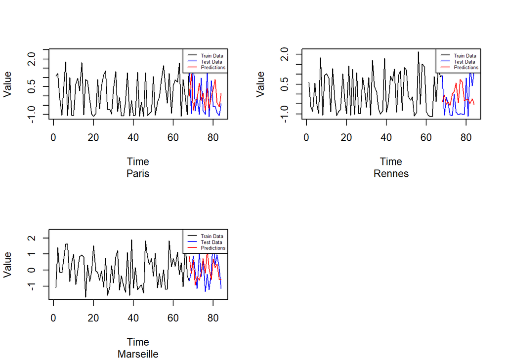

```r
par(mfrow = c(1, 1))
```

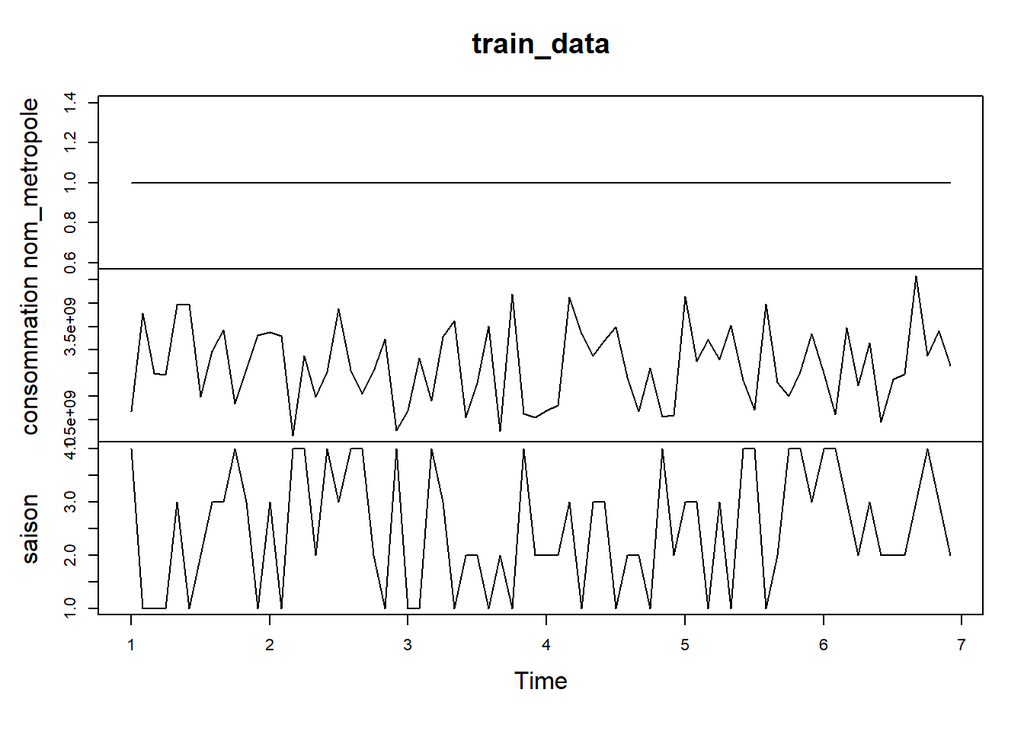

```r
# Modèle SARIMAX avec variable saison
Paris_conso <- subset(donnee_filtre, nom_metropole == "Métropole du Grand Paris")
Marseille_conso <- subset(donnee_filtre, nom_metropole == "Métropole d'Aix-Marseille-Provence")
Rennes_conso<- subset(donnee_filtre, nom_metropole == "Rennes Métropole")

#Application à notre jeu de données
Paris_conso_with_month <- Paris_conso %>% mutate(saison = sapply(month(Paris_conso$date), month_to_season))
Paris_conso_with_month$saison <- as.numeric(factor(Paris_conso_with_month$saison))

Rennes_conso_with_month <- Rennes_conso %>% mutate(saison = sapply(month(Rennes_conso$date), month_to_season))
Rennes_conso_with_month$saison <- as.numeric(factor(Rennes_conso_with_month$saison))

Marseille_conso_with_month <- Marseille_conso %>% mutate(saison = sapply(month(Marseille_conso$date), month_to_season))
Marseille_conso_with_month$saison <- as.numeric(factor(Marseille_conso_with_month$saison))

# Décomposition de l'aspect temporelle pour mieux prendre en compte la baisse aout et la métropole
# Modèle SARIMAX avec variables exogènes
# Créer une série temporelle
ts_data <- ts(Marseille_conso_with_month[, -1], frequency = 12)  # Supprimer la colonne "date" et "consommation"

# Diviser l'échantillon en train et test (par exemple, 80% train et 20% test)

train_data <- subset(Marseille_conso_with_month, format(date, "%Y") <= "2022")
train_data<- ts(train_data[, -1], frequency = 12)
plot(train_data)
```

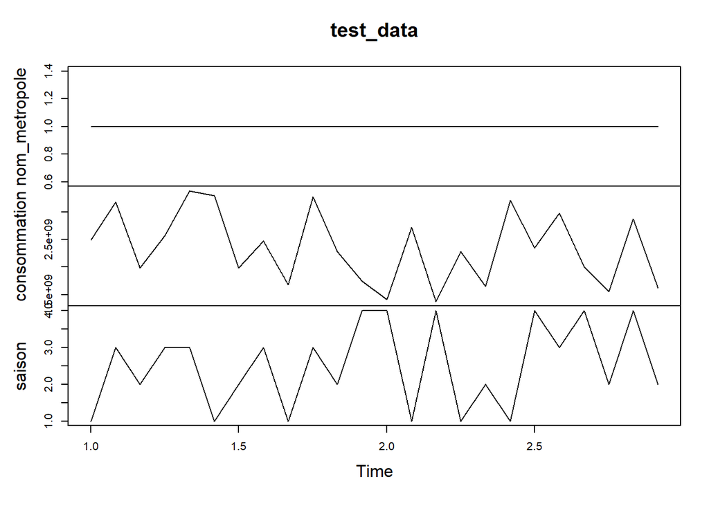

```r
test_data <- subset(Marseille_conso_with_month, format(date, "%Y") >= "2022")
test_data<- ts(test_data[, -1], frequency = 12)
plot(test_data)
```

```r
# Modéliser avec SARIMAX
y_sacle<- scale(train_data[, "consommation"])

# Conserver la moyenne et l'écart type pour la dénormalisation ultérieure
mean_train <- mean(train_data[, "consommation"])
sd_train <- sd(train_data[, "consommation"])

ndiffs(test_data[, "consommation"])
```

```
## [1] 0
```

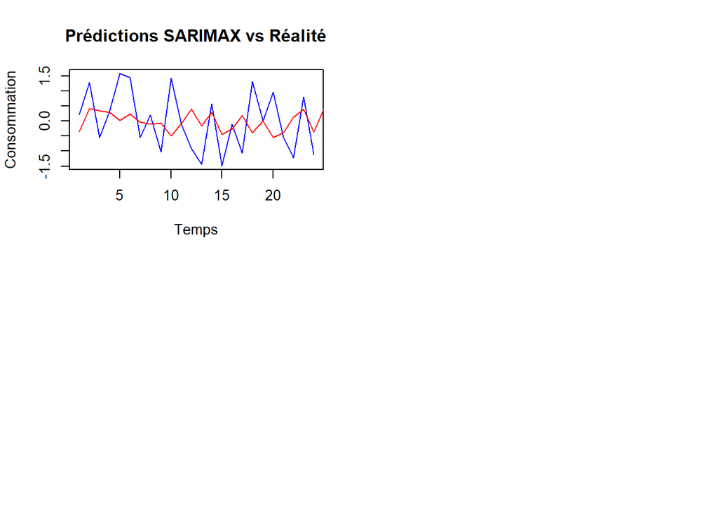

```r
order_arima <- c(1, 0, 2)  # Ordre de l'autorégression
seasonal_order <- c(0,1,1)  # Ordre saisonnier


# Modéliser avec SARIMAX
sarimax_model <- Arima(y_sacle, order = order_arima, seasonal = seasonal_order, xreg = train_data[, "saison"])

# Prédire sur l'échantillon test
sarimax_forecast <- forecast(sarimax_model, xreg = test_data[, "saison"])
# Comparer les prédictions avec les valeurs réelles
# Dénormaliser la série
y_pred_denormalized <- (sarimax_forecast$mean * sd_train) + mean_train


# Créer un dataframe
# Utiliser coredata() pour extraire les valeurs numériques
time_series_values <- as.vector(sarimax_forecast$fitted)
Pred_extrac<- data.frame(value = time_series_values)
par(mfrow = c(2, 2))
plot(scale(test_data[, "consommation"]), type = 'l', col = 'blue', ylab = 'Consommation', xlab = 'Temps', main = 'Prédictions SARIMAX vs Réalité')
lines(Pred_extrac$value, col = 'red')
#legend("topleft", legend = c("Réalité", "Prédictions SARIMAX"), col = c("blue", "red"), lty #= 1

par(mfrow = c(1, 1))
```

```r
# Spécifier le chemin vers votre fichier CSV
chemin_fichier <- "C:/Users/Daniel/Desktop/Mastère ENSAI/Séries temporelles/Projet Environnement/MENSQ_02_previous-1950-2022.csv/MENSQ_02_previous-1950-2022.csv"

# Importer la base de données CSV avec le séparateur ";"
Temperature <- read.csv2(chemin_fichier, sep = ";")

# Sélectionner les deux colonnes spécifiques (remplacez "Colonne1" et "Colonne2" par les noms réels de vos colonnes)
Temperature <- Temperature %>%
  select(AAAAMM, TX)

# Formater la colonne de dates au format "AAAA-MM-01"
Temperature <- Temperature %>%
  mutate(date = as.Date(paste0(AAAAMM, "01"), format = "%Y%m%d"))

Temperature <- Temperature %>%
  select(date, TX)

Temperature <- Temperature %>%
  mutate(TX = as.numeric(TX))

head(Temperature)
```

```
##         date TX
## 1 1950-01-01 NA
## 2 1950-02-01 NA
## 3 1950-03-01 NA
## 4 1950-04-01 NA
## 5 1950-05-01 NA
## 6 1950-06-01 NA
```

```r
# Filtrer les données pour prendre uniquement celles entre 2017 et 2022
Temperature <- Temperature %>%
  filter(date >= as.Date("2017-01-01") & date <= as.Date("2022-12-31"))

# Sélectionner les 72 premières lignes
Temperature <- Temperature %>%
  slice(1:72)

# Afficher les données finales
head(Temperature)
```

```
##         date   TX
## 1 2017-01-01  3.7
## 2 2017-02-01  9.3
## 3 2017-03-01 14.5
## 4 2017-04-01 15.2
## 5 2017-05-01 21.1
## 6 2017-06-01 24.9
```

```r
Paris_conso_with_month_filtred<- Paris_conso_with_month %>%
  filter(date <= as.Date("2022-12-01") )

# Fusionner les dataframes sur la colonne "Date"
Merge_temperature_conso <- merge(Paris_conso_with_month_filtred, Temperature, by = "date")

# Afficher le résultat
head(Merge_temperature_conso)
```

```
##         date            nom_metropole consommation saison   TX
## 1 2017-01-01 Métropole du Grand Paris   8327275293      3  3.7
## 2 2017-02-01 Métropole du Grand Paris   5215213943      3  9.3
## 3 2017-03-01 Métropole du Grand Paris   4167184403      3 14.5
## 4 2017-04-01 Métropole du Grand Paris   2844729053      4 15.2
## 5 2017-05-01 Métropole du Grand Paris   1749229406      4 21.1
## 6 2017-06-01 Métropole du Grand Paris    775053063      4 24.9
```

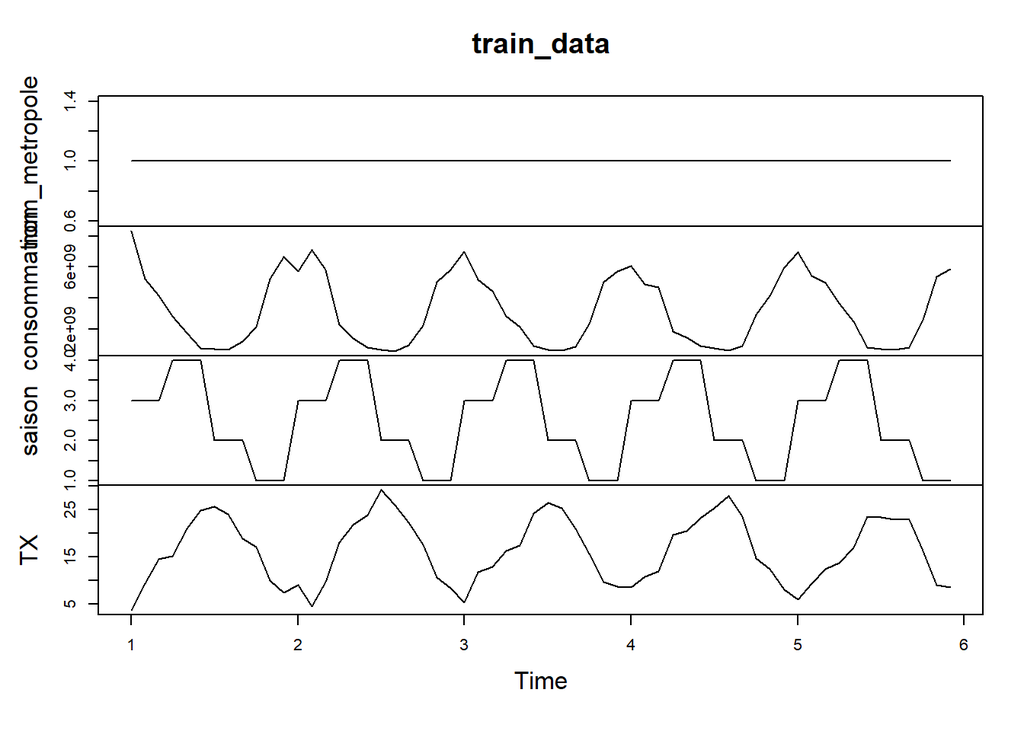

```r
# Décomposition de l'aspect temporelle pour mieux prendre en compte la baisse aout et la métropole
# Modèle SARIMAX avec variables exogènes
# Créer une série temporelle
ts_data <- ts(Merge_temperature_conso[, -1], frequency = 12)  # Supprimer la colonne "date" et "consommation"

# Diviser l'échantillon en train et test (par exemple, 80% train et 20% test)

train_data <- subset(Merge_temperature_conso, format(date, "%Y") <= "2021")
train_data<- ts(train_data[, -1], frequency = 12)
plot(train_data)
```

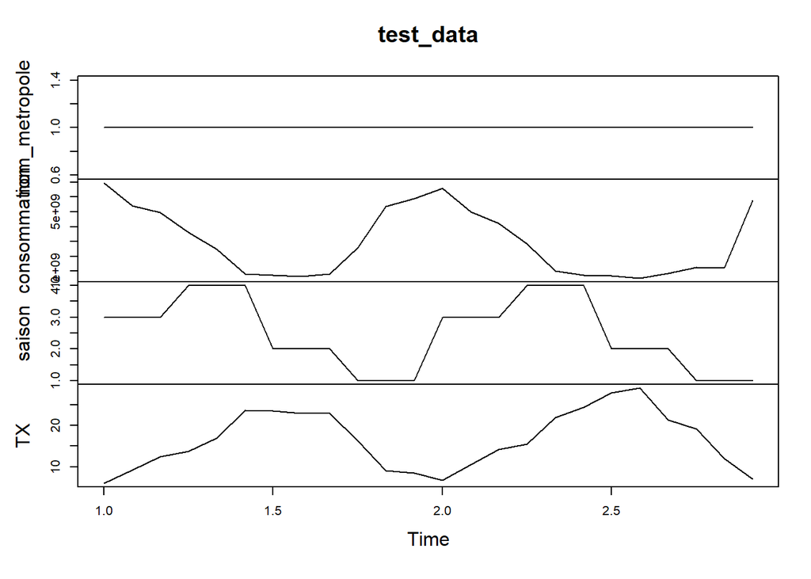

```r
test_data <- subset(Merge_temperature_conso, format(date, "%Y") >= "2021")
test_data<- ts(test_data[, -1], frequency = 12)
plot(test_data)
```

```r
# Modéliser avec SARIMAX
y_sacle<- scale(train_data[, "consommation"])

# Conserver la moyenne et l'écart type pour la dénormalisation ultérieure
mean_train <- mean(train_data[, "consommation"])
sd_train <- sd(train_data[, "consommation"])

ndiffs(test_data[, "consommation"])
```

```
## [1] 0
```

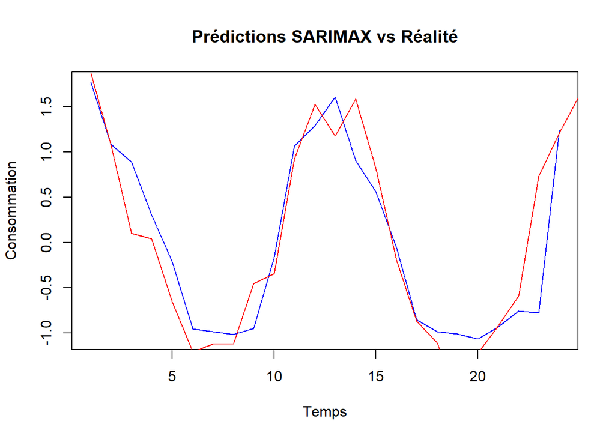

```r
order_arima <- c(3, 0, 1)  # Ordre de l'autorégression
seasonal_order <- c(0,1,1)  # Ordre saisonnier

# Modéliser avec SARIMAX
sarimax_model <- Arima(y_sacle, order = order_arima, seasonal = seasonal_order, xreg = train_data[, c("saison","TX")])

# Prédire sur l'échantillon test
sarimax_forecast <- forecast(sarimax_model, xreg = test_data[, c("saison","TX")])
# Comparer les prédictions avec les valeurs réelles
# Dénormaliser la série
y_pred_denormalized <- (sarimax_forecast$mean * sd_train) + mean_train


# Créer un dataframe
# Utiliser coredata() pour extraire les valeurs numériques
time_series_values <- as.vector(sarimax_forecast$fitted)
Pred_extrac<- data.frame(value = time_series_values)

plot(scale(test_data[, "consommation"]), type = 'l', col = 'blue', ylab = 'Consommation', xlab = 'Temps', main = 'Prédictions SARIMAX vs Réalité')
lines(Pred_extrac$value, col = 'red')
```

```r
#legend("topleft", legend = c("Réalité", "Prédictions SARIMAX"), col = c("blue", "red"), lty #= 1
```